# Sales_Data_EDA

Harshitha Chandrashekar

2024-01-03

# Data preprocessing and Exploratory Data Analysis of Amazon products

## Abstract

**Data Cleaning and Preparation:** We begin by rectifying inconsistencies, handling missing values, and standardizing the dataset, particularly focusing on product pricing and customer ratings. This ensures a solid foundation for accurate analysis.

**Data Analysis:** The analysis phase delves into understanding pricing strategies, customer satisfaction, and product categorization. We explore the relationships between pricing, discounts, and customer ratings to uncover patterns that inform business strategy.

**Data Visualization:** Various visual tools like histograms, bar plots, and scatter plots are employed to illustrate key data trends and insights, making the analysis comprehensible and engaging.

The project aims to extract actionable insights from the dataset, demonstrating the value of a data-driven approach in understanding and optimizing e-commerce strategies, especially in product pricing and customer engagement.

## Data Overview

This dataset comprises a selection of products from specific categories on Amazon India, available at https://www.amazon.in/. It encompasses details about the products, including their prices, discounts, and customer ratings.

**Columns in the Dataset** This dataset consists of 16 columns, but I will primarily concentrate on the specific columns listed below for my analysis.

**Product_Id:** A unique identifier for each product. This can be useful for tracking and referring to specific products.  
**product_name:** The name or title of the product.  
**category:** Provides a hierarchical categorization of each product.  
**discounted_price:** The price of the product after applying the discount.  
**actual_price:** The original price of the product before any discounts.  
**discount_percentage:** The percentage of discount applied to the product.  
**rating:** The average customer rating for the product. This is crucial for understanding customer satisfaction and product quality.  
**rating_count:** The number of ratings a product has received. This can indicate the popularity or customer engagement with the product.  
**user_id:** list of unique identifiers for users who have reviewed the product.  
**user_name:** Names of users who have reviewed the product.  
**img_link:** A link to an image of the product.

## Data Cleaning and Preprocessing

```r
#Read the data in the file
data1 <- read.csv('./Amazon_kaggle.csv')

#Displays the first few rows
head(data1, 3)
```

```
##   product_id
## 1 B07JW9H4J1
## 2 B098NS6PVG
## 3 B096MSW6CT
##                                                                                                                                                                                        product_name
## 1                                Wayona Nylon Braided USB to Lightning Fast Charging and Data Sync Cable Compatible for iPhone 13, 12,11, X, 8, 7, 6, 5, iPad Air, Pro, Mini (3 FT Pack of 1, Grey)
## 2 Ambrane Unbreakable 60W / 3A Fast Charging 1.5m Braided Type C Cable for Smartphones, Tablets, Laptops & other Type C devices, PD Technology, 480Mbps Data Sync, Quick Charge 3.0 (RCT15A, Black)
## 3                                                          Sounce Fast Phone Charging Cable & Data Sync USB Cable Compatible for iPhone 13, 12,11, X, 8, 7, 6, 5, iPad Air, Pro, Mini & iOS Devices
##                                                                            category
## 1 Computers&Accessories|Accessories&Peripherals|Cables&Accessories|Cables|USBCables
## 2 Computers&Accessories|Accessories&Peripherals|Cables&Accessories|Cables|USBCables
## 3 Computers&Accessories|Accessories&Peripherals|Cables&Accessories|Cables|USBCables
##   discounted_price actual_price discount_percentage rating rating_count
## 1             ₹399       ₹1,099                 64%    4.2       24,269
## 2             ₹199         ₹349                 43%      4       43,994
```

[output cut: 33 more lines]

```r
#Displays the column names
colnames(data1)
```

```
##  [1] "product_id"          "product_name"        "category"
##  [4] "discounted_price"    "actual_price"        "discount_percentage"
##  [7] "rating"              "rating_count"        "about_product"
## [10] "user_id"             "user_name"           "review_id"
## [13] "review_title"        "review_content"      "img_link"
## [16] "product_link"
```

```r
#Displays rows and columns
dimensions <- dim(data1)
dimensions
```

```
## [1] 1465   16
```

```r
#Checking Data Types for each Column
sapply(data1, class)
```

```
##          product_id        product_name            category    discounted_price
##         "character"         "character"         "character"         "character"
##        actual_price discount_percentage              rating        rating_count
##         "character"         "character"         "character"         "character"
##       about_product             user_id           user_name           review_id
##         "character"         "character"         "character"         "character"
##        review_title      review_content            img_link        product_link
##         "character"         "character"         "character"         "character"
```

**All the columns are in the ‘character’ data type. Therefore, we need to convert the numerical columns to their appropriate data types and format them accordingly.**

```r
# Replacing "," with nothing in the "Actual Price" and "Discounted Price" columns
data1$actual_price <- gsub(",", "", data1$actual_price)
data1$discounted_price <- gsub(",", "", data1$discounted_price)

#Lets convert the data type of "Discounted Price" and "Actual Price" from "chr" to "num"
data1$discounted_price <- as.numeric(sub("₹", "", data1$discounted_price))
data1$actual_price <- as.numeric(sub("₹", "", data1$actual_price))

#Lets convert the datatype of "Discount Percentage" to "num"

# Replaces '%' and convert to numeric
data1$discount_percentage <- as.numeric(gsub('%', '', data1$discount_percentage))
sapply(data1, class)
```

```
##          product_id        product_name            category    discounted_price
##         "character"         "character"         "character"           "numeric"
##        actual_price discount_percentage              rating        rating_count
##           "numeric"           "numeric"         "character"         "character"
##       about_product             user_id           user_name           review_id
##         "character"         "character"         "character"         "character"
##        review_title      review_content            img_link        product_link
##         "character"         "character"         "character"         "character"
```

```r
# Divide by 100
data1$discount_percentage <- data1$discount_percentage / 100

# Display the 'discount_percentage' column
head(data1$discount_percentage)
```

```
## [1] 0.64 0.43 0.90 0.53 0.61 0.85
```

**Lets inspect the *rating* column**

```r
#Finds the count of all the different ratings in the "Rating" column
rating_counts <- table(data1$rating)
print(rating_counts)
```

```
##
##   |   2 2.3 2.6 2.8 2.9   3 3.1 3.2 3.3 3.4 3.5 3.6 3.7 3.8 3.9   4 4.1 4.2 4.3
##   1   1   1   1   2   1   4   4   2  16  10  26  35  42  86 123 181 244 228 230
## 4.4 4.5 4.6 4.7 4.8   5
## 123  75  17   6   3   3
```

```r
#Inspecting the strange row in the rating column having "|" as a rating
Strange_row <- data1[data1$rating == "|", ]
Strange_row
```

```
##      product_id
## 1280 B08L12N5H1
##                                                                                                                                                     product_name
## 1280 Eureka Forbes car Vac 100 Watts Powerful Suction Vacuum Cleaner with Washable HEPA Filter, 3 Accessories,Compact,Light Weight & Easy to use (Black and Red)
##                                                                                                   category
## 1280 Home&Kitchen|Kitchen&HomeAppliances|Vacuum,Cleaning&Ironing|Vacuums&FloorCare|Vacuums|HandheldVacuums
##      discounted_price actual_price discount_percentage rating rating_count
## 1280             2099         2499                0.16      |          992
##                                                                                                                                                                            about_product
## 1280 No Installation is provided for this product|100 Watts Powerful Motor|Powerful Suction|In-Built LED Torch|Range of accessories for different cleaning needs|Fit type: Universal Fit
##                                                                                                                                                                                                                                      user_id
## 1280 AGTDSNT2FKVYEPDPXAA673AIS44A,AER2XFSWNN4LAUCJ55IY5SOMF7WA,AE3MSW6H3AL6F3ZGR5LCN5AHJO6A,AG5OL5WIIPJBY25HISJLM5K2UBTQ,AGHFSIBYVYXUGSNYUDAHBGOIZ3KQ,AHYH6AZT3U3U44CDW5Y563UYIIUA,AFLOAOURRZZZGFBF7F6IKGXRB6NQ,AGNWBYEVAIII4MPQNKN3LFVOHYZQ
##                                                                                              user_name
## 1280 Divya,Dr Nefario,Deekshith,Preeti,Prasanth R,Pradeep kashiram Tetgure.,Abhijin Janardhan,Prashant
##                                                                                                                    review_id
## 1280 R2KKTKM4M9RDVJ,R1O692MZOBTE79,R2WRSEWL56SOS4,R3VZRQJOKCBSH4,R2QI4626ASSCIT,R1TFFJ5ON6ATEO,R14JK9VQCXXEKU,R1V4J4B7RXHG8T
##                                                                                                                                           review_title
## 1280 Decent product,doesn't pick up sand,Ok ok,Must Buy,Good one for basic use with normal suction power,Super,First review,Perfect product for my car
##                                                                                                                                                                                                                                                                                                          …
## 1280 Does the job well,doesn't work on sand. though the suction is very good, the sand stays back no matter which lead you use.,Ok ok,Easy to use product (I used it for the first time without knowing the know-how of its use). Cleans almost 90% of your mess inside the car. Highly recommended.,Pros…
##                                                                                                   img_link
## 1280 https://m.media-amazon.com/images/W/WEBP_402378-T1/images/I/41lZEy8e9DL._SX300_SY300_QL70_FMwebp_.jpg
##                                                                                                                  product_link
## 1280 https://www.amazon.in/Eureka-Forbes-Vacuum-Cleaner-Washable/dp/B08L12N5H1/ref=sr_1_295?qid=1672923607&s=kitchen&sr=1-295
```

**After conducting a search for the product on the Amazon website, I discovered that the rating is 3.9. As a result, I intend to make a replacement.**

```r
# Replacing "|" with "3.9" and converting it to numeric
data1$rating <- as.numeric(gsub("\\|", "3.9", data1$rating))
```

**Let’s remove the “,” and convert the data type of *rating_count* column**

```r
data1$rating_count <- as.numeric(sub(",", "", data1$rating_count))
```

**Check for *missing values***

```r
missing_values <- colSums(is.na(data1))
missing_values
```

```
##          product_id        product_name            category    discounted_price
##                   0                   0                   0                   0
##        actual_price discount_percentage              rating        rating_count
##                   0                   0                   0                  49
##       about_product             user_id           user_name           review_id
##                   0                   0                   0                   0
##        review_title      review_content            img_link        product_link
##                   0                   0                   0                   0
```

```r
# Created a new data frame 'df1' with selected columns
df1 <- subset(data1, select = c(product_id, product_name, category, discounted_price, actual_price, discount_percentage, rating, rating_count))

# Splitting the strings in the category column
category_split <- strsplit(data1$category, "|", fixed = TRUE)
category_split_df <- as.data.frame(do.call(rbind, category_split))
# Renaming the "Category Column" with only the required hirarchial category columns
colnames(category_split_df) <- c('Category_1', 'Category_2', 'Category_3')
head(category_split_df)
```

```
##              Category_1              Category_2         Category_3     NA
## 1 Computers&Accessories Accessories&Peripherals Cables&Accessories Cables
## 2 Computers&Accessories Accessories&Peripherals Cables&Accessories Cables
## 3 Computers&Accessories Accessories&Peripherals Cables&Accessories Cables
## 4 Computers&Accessories Accessories&Peripherals Cables&Accessories Cables
## 5 Computers&Accessories Accessories&Peripherals Cables&Accessories Cables
## 6 Computers&Accessories Accessories&Peripherals Cables&Accessories Cables
##          NA                    NA                      NA
## 1 USBCables Computers&Accessories Accessories&Peripherals
## 2 USBCables Computers&Accessories Accessories&Peripherals
## 3 USBCables Computers&Accessories Accessories&Peripherals
## 4 USBCables Computers&Accessories Accessories&Peripherals
## 5 USBCables Computers&Accessories Accessories&Peripherals
## 6 USBCables Computers&Accessories Accessories&Peripherals
```

```r
# Adding the categories to the new dataframe
df1$Category_1 <- category_split_df$Category_1
df1$Category_2 <- category_split_df$Category_2
df1$Category_3 <- category_split_df$Category_3

# Removing the 'category' column from 'df1'
df1$category <- NULL

#Display the new dataframe
head(df1)
```

```
##   product_id
## 1 B07JW9H4J1
## 2 B098NS6PVG
## 3 B096MSW6CT
## 4 B08HDJ86NZ
## 5 B08CF3B7N1
## 6 B08Y1TFSP6
##                                                                                                                                                                                              product_name
## 1                                      Wayona Nylon Braided USB to Lightning Fast Charging and Data Sync Cable Compatible for iPhone 13, 12,11, X, 8, 7, 6, 5, iPad Air, Pro, Mini (3 FT Pack of 1, Grey)
## 2       Ambrane Unbreakable 60W / 3A Fast Charging 1.5m Braided Type C Cable for Smartphones, Tablets, Laptops & other Type C devices, PD Technology, 480Mbps Data Sync, Quick Charge 3.0 (RCT15A, Black)
## 3                                                                Sounce Fast Phone Charging Cable & Data Sync USB Cable Compatible for iPhone 13, 12,11, X, 8, 7, 6, 5, iPad Air, Pro, Mini & iOS Devices
## 4 boAt Deuce USB 300 2 in 1 Type-C & Micro USB Stress Resistant, Tangle-Free, Sturdy Cable with 3A Fast Charging & 480mbps Data Transmission, 10000+ Bends Lifespan and Extended 1.5m Length(Martian Red)
## 5                                                                                          Portronics Konnect L 1.2M Fast Charging 3A 8 Pin USB Cable with Charge & Sync Function for iPhone, iPad (Grey)
## 6       pTron Solero TB301 3A Type-C Data and Fast Charging Cable, Made in India, 480Mbps Data Sync, Strong and Durable 1.5-Meter Nylon Braided USB Cable for Type-C Devices for Charging Adapter (Black)
##   discounted_price actual_price discount_percentage rating rating_count
## 1              399         1099                0.64    4.2        24269
## 2              199          349                0.43    4.0        43994
## 3              199         1899                0.90    3.9         7928
## 4              329          699                0.53    4.2        94363
## 5              154          399                0.61    4.2        16905
## 6              149         1000                0.85    3.9        24871
##              Category_1              Category_2         Category_3
## 1 Computers&Accessories Accessories&Peripherals Cables&Accessories
## 2 Computers&Accessories Accessories&Peripherals Cables&Accessories
## 3 Computers&Accessories Accessories&Peripherals Cables&Accessories
## 4 Computers&Accessories Accessories&Peripherals Cables&Accessories
## 5 Computers&Accessories Accessories&Peripherals Cables&Accessories
## 6 Computers&Accessories Accessories&Peripherals Cables&Accessories
```

**Now, lets fix the strings in all the *category* columns**

```r
# Checking the unique values in "Category 1"
category_1_counts <- table(df1$Category_1)
category_1_counts
```

```
##
##         Car&Motorbike Computers&Accessories           Electronics
##                     1                   453                   526
##   Health&PersonalCare          Home&Kitchen       HomeImprovement
##                     1                   448                     2
##    MusicalInstruments        OfficeProducts            Toys&Games
##                     2                    31                     1
```

```r
# install.packages("stringr")
library(stringr)


# Fixing Strings in the Category_1 Column
df1$Category_1 <- str_replace_all(df1$Category_1, c('&' = ' & ',
                                                    'OfficeProducts' = 'Office Products',
                                                    'MusicalInstruments' = 'Musical Instruments',
                                                    'HomeImprovement' = 'Home Improvement'))


# Checking the unique values in "Category 2"
category_2_counts <- table(df1$Category_2)
category_2_counts
```

```
##
##                             Accessories                 Accessories&Peripherals
##                                      14                                     381
##                             Arts&Crafts                     Cameras&Photography
##                                       1                                      16
##                          CarAccessories                              Components
##                                       1                                       5
##                          CraftMaterials                              Electrical
##                                       7                                       2
##             ExternalDevices&DataStorage GeneralPurposeBatteries&BatteryChargers
##                                      18                                      14
##          Headphones,Earbuds&Accessories              Heating,Cooling&AirQuality
##                                      66                                     116
##                               HomeAudio           HomeMedicalSupplies&Equipment
##                                      16                                       1
##                HomeStorage&Organization                    HomeTheater,TV&Video
##                                      16                                     162
##                          Kitchen&Dining                  Kitchen&HomeAppliances
##                                       1                                     308
##                                 Laptops                             Microphones
##                                       1                                       2
##                     Mobiles&Accessories                                Monitors
##                                     161                                       2
##                       NetworkingDevices                       OfficeElectronics
##                                      34                                       4
##                     OfficePaperProducts                        PowerAccessories
##                                      27                                       1
##               Printers,Inks&Accessories                                 Tablets
##                                      11                                       1
##                      WearableTechnology
##                                      76
```

```r
#Fixing Strings in Category_2 column
df1$Category_2 <- gsub('&', ' & ', df1$Category_2)
df1$Category_2 <- gsub(',', ', ', df1$Category_2)
df1$Category_2 <- gsub('HomeAppliances', 'Home Appliances', df1$Category_2)
df1$Category_2 <- gsub('AirQuality', 'Air Quality', df1$Category_2)
df1$Category_2 <- gsub('WearableTechnology', 'Wearable Technology', df1$Category_2)
df1$Category_2 <- gsub('NetworkingDevices', 'Networking Devices', df1$Category_2)
df1$Category_2 <- gsub('OfficePaperProducts', 'Office Paper Products', df1$Category_2)
df1$Category_2 <- gsub('ExternalDevices', 'External Devices', df1$Category_2)
df1$Category_2 <- gsub('DataStorage', 'Data Storage', df1$Category_2)
df1$Category_2 <- gsub('HomeStorage', 'Home Storage', df1$Category_2)
df1$Category_2 <- gsub('HomeAudio', 'Home Audio', df1$Category_2)
df1$Category_2 <- gsub('GeneralPurposeBatteries', 'General Purpose Batteries', df1$Category_2)
df1$Category_2 <- gsub('BatteryChargers', 'Battery Chargers', df1$Category_2)
df1$Category_2 <- gsub('CraftMaterials', 'Craft Materials', df1$Category_2)
df1$Category_2 <- gsub('OfficeElectronics', 'Office Electronics', df1$Category_2)
df1$Category_2 <- gsub('PowerAccessories', 'Power Accessories', df1$Category_2)
df1$Category_2 <- gsub('CarAccessories', 'Car Accessories', df1$Category_2)
df1$Category_2 <- gsub('HomeMedicalSupplies', 'Home Medical Supplies', df1$Category_2)
df1$Category_2 <- gsub('HomeTheater', 'Home Theater', df1$Category_2)


# Checking the unique values in "Category 3"
category_3_counts <- table(df1$Category_3)

#Fixing Strings in Category_3 column
df1$Category_3 <- gsub('&', ' & ', df1$Category_3)
df1$Category_3 <- gsub(',', ', ', df1$Category_3)
df1$Category_3 <- gsub("([a-z])([A-Z])", "\\1 \\2", df1$Category_3)
df1$Category_3 <- gsub('PCGaming Peripherals', 'PC Gaming Peripherals', df1$Category_3)
df1$Category_3 <- gsub('USBHubs', 'USB Hubs', df1$Category_3)
df1$Category_3 <- gsub('USBGadgets', 'USB Gadgets', df1$Category_3)

head(df1)
```

```
##   product_id
## 1 B07JW9H4J1
## 2 B098NS6PVG
## 3 B096MSW6CT
## 4 B08HDJ86NZ
## 5 B08CF3B7N1
## 6 B08Y1TFSP6
##                                                                                                                                                                                              product_name
## 1                                      Wayona Nylon Braided USB to Lightning Fast Charging and Data Sync Cable Compatible for iPhone 13, 12,11, X, 8, 7, 6, 5, iPad Air, Pro, Mini (3 FT Pack of 1, Grey)
## 2       Ambrane Unbreakable 60W / 3A Fast Charging 1.5m Braided Type C Cable for Smartphones, Tablets, Laptops & other Type C devices, PD Technology, 480Mbps Data Sync, Quick Charge 3.0 (RCT15A, Black)
## 3                                                                Sounce Fast Phone Charging Cable & Data Sync USB Cable Compatible for iPhone 13, 12,11, X, 8, 7, 6, 5, iPad Air, Pro, Mini & iOS Devices
## 4 boAt Deuce USB 300 2 in 1 Type-C & Micro USB Stress Resistant, Tangle-Free, Sturdy Cable with 3A Fast Charging & 480mbps Data Transmission, 10000+ Bends Lifespan and Extended 1.5m Length(Martian Red)
## 5                                                                                          Portronics Konnect L 1.2M Fast Charging 3A 8 Pin USB Cable with Charge & Sync Function for iPhone, iPad (Grey)
## 6       pTron Solero TB301 3A Type-C Data and Fast Charging Cable, Made in India, 480Mbps Data Sync, Strong and Durable 1.5-Meter Nylon Braided USB Cable for Type-C Devices for Charging Adapter (Black)
##   discounted_price actual_price discount_percentage rating rating_count
## 1              399         1099                0.64    4.2        24269
## 2              199          349                0.43    4.0        43994
## 3              199         1899                0.90    3.9         7928
## 4              329          699                0.53    4.2        94363
## 5              154          399                0.61    4.2        16905
## 6              149         1000                0.85    3.9        24871
##                Category_1                Category_2           Category_3
## 1 Computers & Accessories Accessories & Peripherals Cables & Accessories
## 2 Computers & Accessories Accessories & Peripherals Cables & Accessories
## 3 Computers & Accessories Accessories & Peripherals Cables & Accessories
## 4 Computers & Accessories Accessories & Peripherals Cables & Accessories
## 5 Computers & Accessories Accessories & Peripherals Cables & Accessories
## 6 Computers & Accessories Accessories & Peripherals Cables & Accessories
```

**Lets remove whitespaces from *Product_id* column**

```r
df1$product_id <- trimws(df1$product_id)
head(df1)
```

```
##   product_id
## 1 B07JW9H4J1
## 2 B098NS6PVG
## 3 B096MSW6CT
## 4 B08HDJ86NZ
## 5 B08CF3B7N1
## 6 B08Y1TFSP6
##                                                                                                                                                                                              product_name
## 1                                      Wayona Nylon Braided USB to Lightning Fast Charging and Data Sync Cable Compatible for iPhone 13, 12,11, X, 8, 7, 6, 5, iPad Air, Pro, Mini (3 FT Pack of 1, Grey)
## 2       Ambrane Unbreakable 60W / 3A Fast Charging 1.5m Braided Type C Cable for Smartphones, Tablets, Laptops & other Type C devices, PD Technology, 480Mbps Data Sync, Quick Charge 3.0 (RCT15A, Black)
## 3                                                                Sounce Fast Phone Charging Cable & Data Sync USB Cable Compatible for iPhone 13, 12,11, X, 8, 7, 6, 5, iPad Air, Pro, Mini & iOS Devices
## 4 boAt Deuce USB 300 2 in 1 Type-C & Micro USB Stress Resistant, Tangle-Free, Sturdy Cable with 3A Fast Charging & 480mbps Data Transmission, 10000+ Bends Lifespan and Extended 1.5m Length(Martian Red)
## 5                                                                                          Portronics Konnect L 1.2M Fast Charging 3A 8 Pin USB Cable with Charge & Sync Function for iPhone, iPad (Grey)
## 6       pTron Solero TB301 3A Type-C Data and Fast Charging Cable, Made in India, 480Mbps Data Sync, Strong and Durable 1.5-Meter Nylon Braided USB Cable for Type-C Devices for Charging Adapter (Black)
##   discounted_price actual_price discount_percentage rating rating_count
## 1              399         1099                0.64    4.2        24269
## 2              199          349                0.43    4.0        43994
## 3              199         1899                0.90    3.9         7928
## 4              329          699                0.53    4.2        94363
## 5              154          399                0.61    4.2        16905
## 6              149         1000                0.85    3.9        24871
##                Category_1                Category_2           Category_3
## 1 Computers & Accessories Accessories & Peripherals Cables & Accessories
## 2 Computers & Accessories Accessories & Peripherals Cables & Accessories
## 3 Computers & Accessories Accessories & Peripherals Cables & Accessories
## 4 Computers & Accessories Accessories & Peripherals Cables & Accessories
## 5 Computers & Accessories Accessories & Peripherals Cables & Accessories
## 6 Computers & Accessories Accessories & Peripherals Cables & Accessories
```

**In the rating column, we could further segregate the ratings based on different categories. Lets create a new column called *Rating_Score* and display the categories for ratings.**

```r
# Adding Categories to the "Rating" Column
df1$Rating_Score <- ifelse(df1$rating < 2.0, 'Poor',
                           ifelse(df1$rating < 3.0, 'Below Average',
                                  ifelse(df1$rating < 4.0, 'Average',
                                         ifelse(df1$rating < 5.0, 'Above Average',
                                                ifelse(df1$rating == 5.0, 'Excellent', NA)))))

head(df1)
```

```
##   product_id
## 1 B07JW9H4J1
## 2 B098NS6PVG
## 3 B096MSW6CT
## 4 B08HDJ86NZ
## 5 B08CF3B7N1
## 6 B08Y1TFSP6
##                                                                                                                                                                                              product_name
## 1                                      Wayona Nylon Braided USB to Lightning Fast Charging and Data Sync Cable Compatible for iPhone 13, 12,11, X, 8, 7, 6, 5, iPad Air, Pro, Mini (3 FT Pack of 1, Grey)
## 2       Ambrane Unbreakable 60W / 3A Fast Charging 1.5m Braided Type C Cable for Smartphones, Tablets, Laptops & other Type C devices, PD Technology, 480Mbps Data Sync, Quick Charge 3.0 (RCT15A, Black)
## 3                                                                Sounce Fast Phone Charging Cable & Data Sync USB Cable Compatible for iPhone 13, 12,11, X, 8, 7, 6, 5, iPad Air, Pro, Mini & iOS Devices
## 4 boAt Deuce USB 300 2 in 1 Type-C & Micro USB Stress Resistant, Tangle-Free, Sturdy Cable with 3A Fast Charging & 480mbps Data Transmission, 10000+ Bends Lifespan and Extended 1.5m Length(Martian Red)
## 5                                                                                          Portronics Konnect L 1.2M Fast Charging 3A 8 Pin USB Cable with Charge & Sync Function for iPhone, iPad (Grey)
## 6       pTron Solero TB301 3A Type-C Data and Fast Charging Cable, Made in India, 480Mbps Data Sync, Strong and Durable 1.5-Meter Nylon Braided USB Cable for Type-C Devices for Charging Adapter (Black)
##   discounted_price actual_price discount_percentage rating rating_count
```

[output cut: 20 more lines]

```r
# Checking the data type of "Rating Score" column
column_type <- class(df1$Rating_Score)
column_type
```

```
## [1] "character"
```

**I want to create a new column that tells us the difference in price between actual and discounted prices. Lets call it *Price_Difference***

```r
df1$Price_difference <- df1$actual_price - df1$discounted_price
```

**Finalizing the *df1* dataframe**

```r
# Reorder columns by specifying the desired order
df1 <- df1[, c("product_id", "Category_1", "Category_2", "Category_3", "product_name", "discounted_price", "actual_price", "Price_difference", "discount_percentage", "rating", "Rating_Score", "rating_count")]


# Renaming all the columns
colnames(df1) <- c("Product_Id", "Category_1", "Category_2", "Category_3", "Product_Name",
                   "Discounted_Price", "Actual_Price", "Price_difference", "Discount_Percentage", "Rating",
                   "Rating_Score", "Rating_Count")


# Display the re-ordered columns
head(df1)
```

```
##   Product_Id              Category_1                Category_2
## 1 B07JW9H4J1 Computers & Accessories Accessories & Peripherals
## 2 B098NS6PVG Computers & Accessories Accessories & Peripherals
## 3 B096MSW6CT Computers & Accessories Accessories & Peripherals
## 4 B08HDJ86NZ Computers & Accessories Accessories & Peripherals
## 5 B08CF3B7N1 Computers & Accessories Accessories & Peripherals
## 6 B08Y1TFSP6 Computers & Accessories Accessories & Peripherals
##             Category_3
## 1 Cables & Accessories
## 2 Cables & Accessories
## 3 Cables & Accessories
## 4 Cables & Accessories
## 5 Cables & Accessories
## 6 Cables & Accessories
##                                                                                                                                                                                              Product_Name
```

[output cut: 20 more lines]

**Category_1, Category_2, Category_3, Price_Difference, Rating_Score** are the new variables creating using existing columns.

## Data Analysis and Visualization

### Products Distribution:

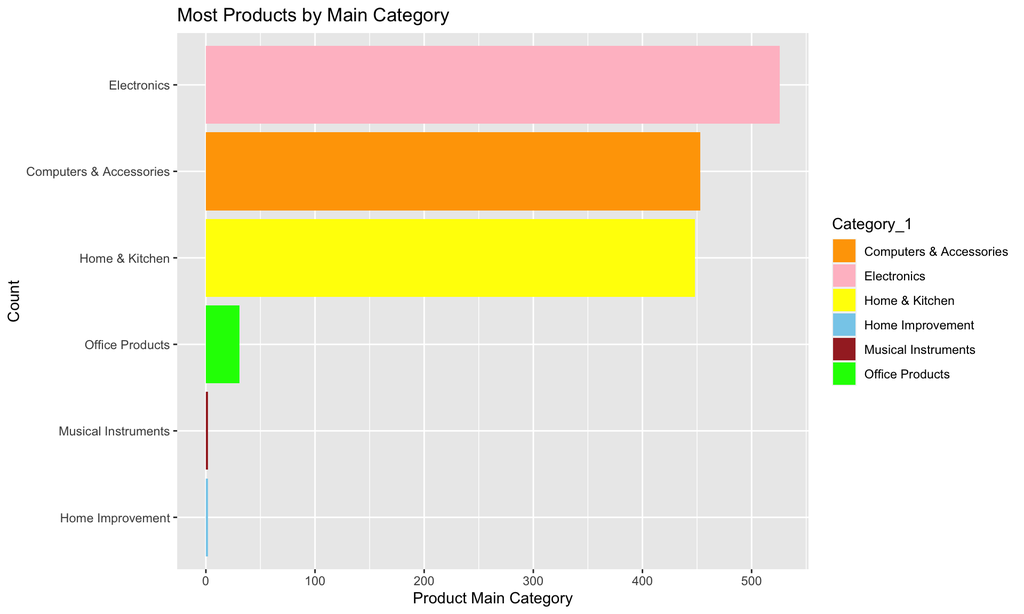

```r
# Get top 5 main categories
most_main_items <- df1 %>%
  count(Category_1) %>%
  top_n(5, n) %>%
  arrange(desc(n))

# Get top 10 sub categories
most_sub_items <- df1 %>%
  count(Category_2) %>%
  top_n(10, n) %>%
  arrange(desc(n))

# Color palette
color_palette <- c("orange", "pink", "yellow", "skyblue", "brown", "green")

# Plotting
p1 <- ggplot(most_main_items, aes(x = reorder(Category_1, n), y = n, fill = Category_1)) +
  geom_bar(stat = "identity") +
  coord_flip() +
  scale_fill_manual(values = color_palette) +
  labs(title = "Most Products by Main Category", x = "Count", y = "Product Main Category")

p1
```

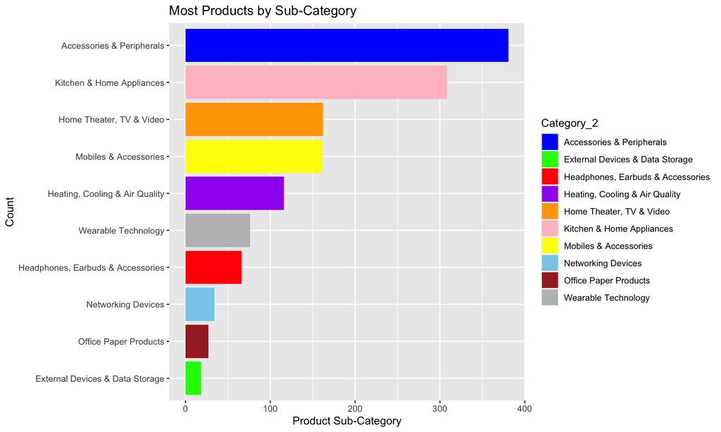

```r
# Get top 5 main categories
most_main_items <- df1 %>%
  count(Category_1) %>%
  top_n(5, n) %>%
  arrange(desc(n))

# Get top 10 sub categories
most_sub_items <- df1 %>%
  count(Category_2) %>%
  top_n(10, n) %>%
  arrange(desc(n))

# Color palette
color_palette <- c("blue", "green", "red", "purple", "orange", "pink", "yellow", "skyblue", "brown", "grey")

# Plotting
p2 <- ggplot(most_sub_items, aes(x = reorder(Category_2, n), y = n, fill = Category_2)) +
  geom_bar(stat = "identity") +
  coord_flip() +
  scale_fill_manual(values = color_palette) +
  labs(title = "Most Products by Sub-Category", x = "Count", y = "Product Sub-Category")

p2
```

### Ratings Analysis

**1. Distribution of Rattings**

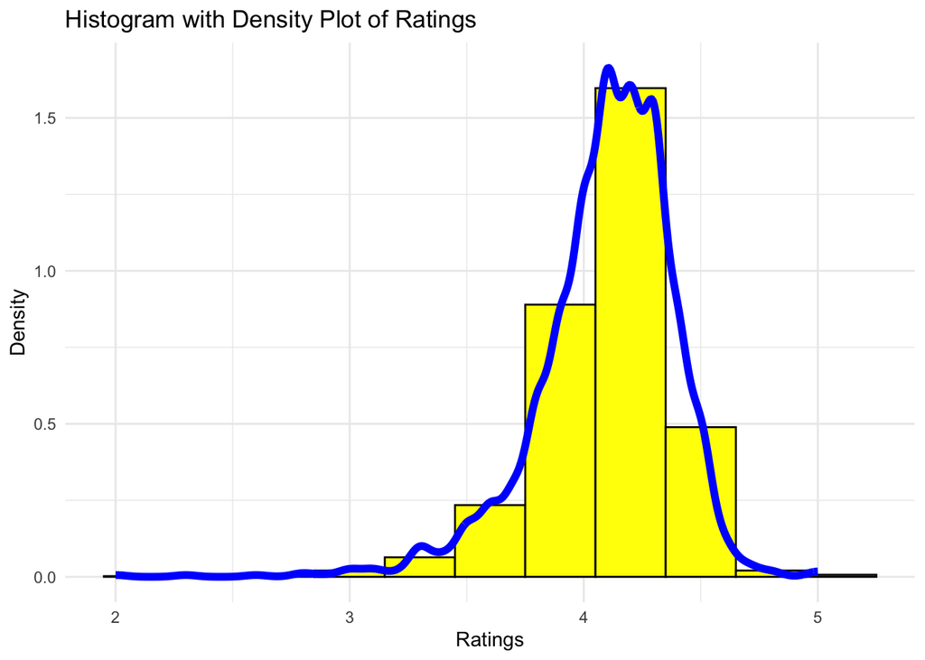

```r
ggplot(df1, aes(x=Rating)) +
  geom_histogram(aes(y=..density..), # Histogram with density on y-axis
                 binwidth=0.3, # Adjust binwidth as needed
                 fill="yellow",
                 color="black") +
  geom_density(col="blue", lwd=2) + # Density plot
  theme_minimal() +
  labs(title="Histogram with Density Plot of Ratings", x="Ratings", y="Density")
```

The histogram shows the distribution of product ratings. The ratings are fairly normally distributed, with a slight skew towards higher ratings. This indicates that a majority of products have ratings in the higher range.

**2. Popular Products based on Rating Count**

Let’s analyze the popularity of products based on the number of ratings received. We’ll identify and visualize the top products in terms of rating count, which can provide insights into the most engaged-with products by customers.

[figure not shown]

```r
# Sorting the dataframe by Rating_Count
df_sorted_by_rating_count <- df1 %>%
  arrange(desc(Rating_Count))

# Selecting the top products
top_10_products <- head(df_sorted_by_rating_count, 10)

# Define your custom labels here
custom_labels <- c("Prod A", "Prod B", "Prod C", "Prod D", "Prod E", "Prod F", "Prod G", "Prod H", "Prod I", "Prod J")

# Plotting the top 10 products based on Rating Count with custom labels
ggplot(top_10_products, aes(x = reorder(Product_Name, Rating_Count), y = Rating_Count)) +
  geom_bar(stat = "identity", fill = "pink") +
  coord_flip() +  # Flip the coordinates to match the seaborn plot
  scale_x_discrete(labels = custom_labels) +
  labs(title = 'Top 10 Products by Rating Count',
       x = 'Product Name',
       y = 'Rating Count') +
  theme_minimal() +
  ylim(c(0, 100000))
```

where, Prod A = boAt Deuce USB 300 2 in 1 Type-C & Micro USB Stress Resistant, Sturdy Cable with 3A Fast Charging & 480mbps Data Transmission, 10000+ Bends Lifespan and Extended 1.5m Length(Mercurial Black)  
Prod B = boAt Rugged v3 Extra Tough Unbreakable Braided Micro USB Cable 1.5 Meter (Black)  
Prod C = boAt Deuce USB 300 2 in 1 Type-C & Micro USB Stress Resistant, Tangle-Free, Sturdy Cable with 3A Fast Charging & 480mbps Data Transmission, 10000+ Bends Lifespan and Extended 1.5m Length(Martian Red)  
Prod D = TP-Link USB Bluetooth Adapter for PC, 5.0 Bluetooth Dongle Receiver (UB500) Supports Windows 11/10/8.1/7 for Desktop, Laptop, Mouse, Keyboard, Printers, Headsets, Speakers, PS4/ Xbox Controllers  
Prod E = boAt Rockerz 400 Bluetooth On Ear Headphones With Mic With Upto 8 Hours Playback & Soft Padded Ear Cushions(Grey/Green)  
Prod F = Sennheiser CX 80S in-Ear Wired Headphones with in-line One-Button Smart Remote with Microphone Black

The bar chart above displays the top products by rating count. This visualization helps in identifying which products are most popular among customers in terms of engagement, as reflected by the number of ratings received.

let’s analyze pricing and discount data.Our analysis could include:  
1. The distribution of actual and discounted prices.  
2. The relationship between discount percentage and price.  
3. How ratings impact pricing.

**1. The distribution of actual and discounted prices.**  
I will plot the distribution of actual and discounted prices with histograms. This will give us an understanding of the range and common price points for these products

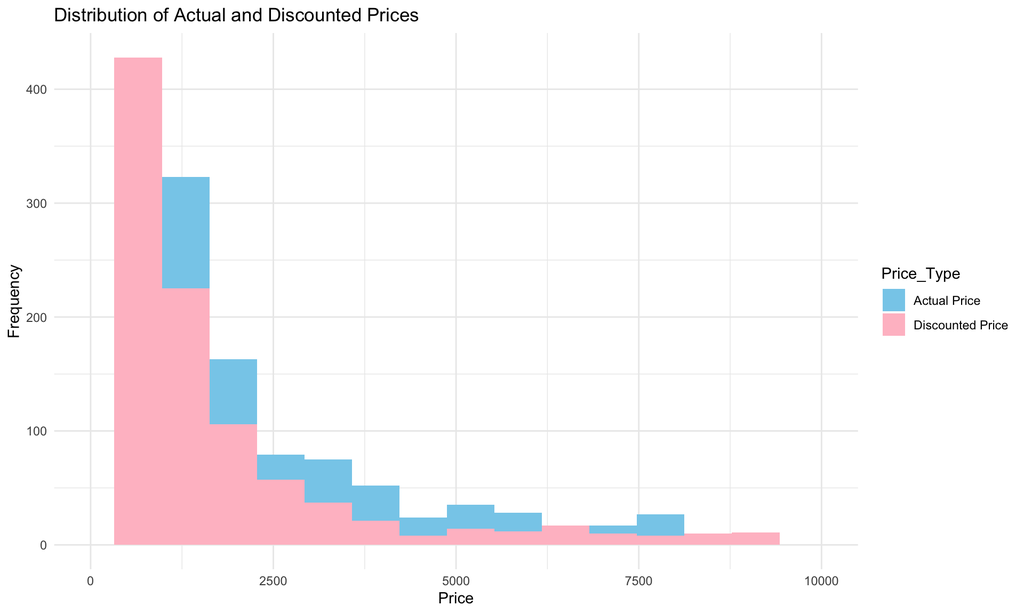

```r
# Creating separate dataframes for actual and discounted prices with the same column names
actual_prices <- df1 %>% select(Price = Actual_Price) %>% mutate(Price_Type = "Actual Price")
discounted_prices <- df1 %>% select(Price = Discounted_Price) %>% mutate(Price_Type = "Discounted Price")

# Combining the dataframes
combined_prices <- rbind(actual_prices, discounted_prices)

# Creating the histogram

ggplot(combined_prices, aes(x = Price, fill = Price_Type)) +
  geom_histogram(aes(y = ..count..), position = "identity", binwidth = 650) + # Adjust binwidth as needed
  scale_fill_manual(values = c("Actual Price" = "skyblue", "Discounted Price" = "pink")) +
  labs(title = "Distribution of Actual and Discounted Prices",
       x = "Price",
       y = "Frequency") +
  theme_minimal() +
  theme(legend.position = "right") +
  xlim(c(0, 10000))
```

Above is the Histogram that shows the distribution of both actual and discounted prices for the products. **It indicates the typical price ranges and how they differ between the actual and discounted prices. The discounted prices are generally lower**, as expected.

**2. Co-relation between actual price and discounted price**

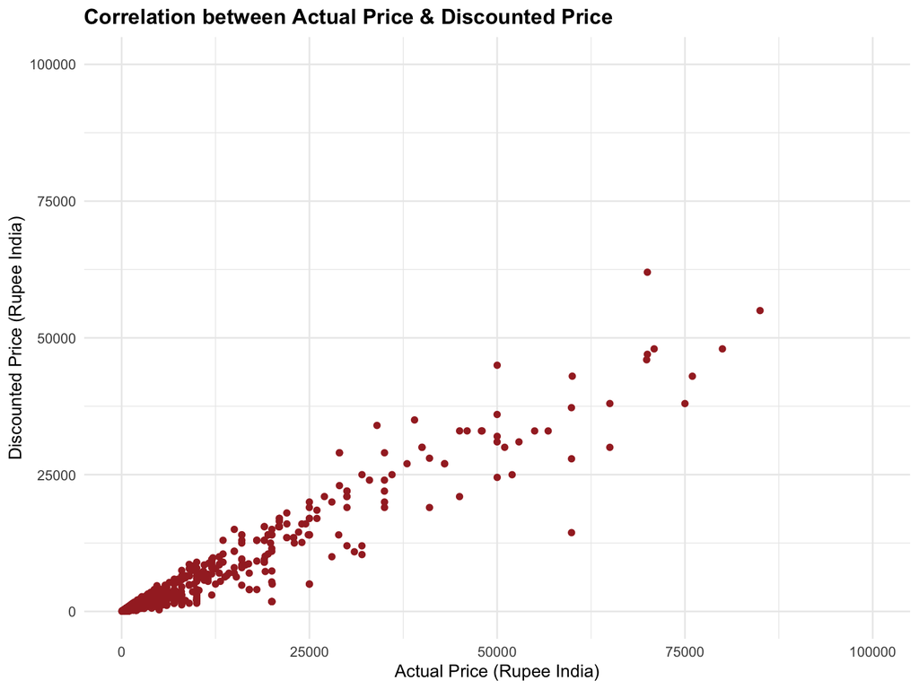

```r
library(ggplot2)
library(corrplot)
# Create the scatter plot of Actual Price vs Discounted Price with defined axis limits
ggplot(df1, aes(x = Actual_Price, y = Discounted_Price)) +
  geom_point(color = "brown") +
  labs(x = 'Actual Price (Rupee India)', y = 'Discounted Price (Rupee India)',
       title = 'Correlation between Actual Price & Discounted Price') +
  theme_minimal() +
  theme(plot.title = element_text(face = "bold")) +
  xlim(0, 100000) +
  ylim(0, 100000)
```

The scatter plot illustrates the relationship between the actual price and discounted price. There’s a general trend that as the actual price increases, the discounted price also increases. This plot helps to visualize how discounts are applied across different price ranges.

**3. Price and Discount Analysis**  
Next, I will investigate the relationship between the discount percentage and the actual price of the products, overlaying the ratings, by using a scatter plot.

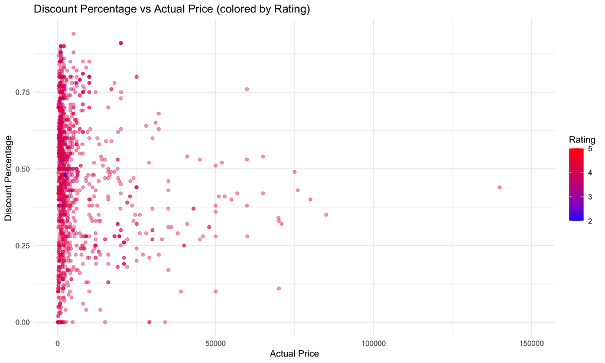

```r
x_range <- c(0, 150000)
y_range <- c(0, max(df1$Discount_Percentage, na.rm = TRUE))

# Creating the scatter plot with adjusted x and y axis limits
ggplot(df1, aes(x = Actual_Price, y = Discount_Percentage, color = Rating)) +
  geom_point(alpha = 0.4) +
  scale_color_gradient(low = "blue", high = "red") +
  labs(title = 'Discount Percentage vs Actual Price (colored by Rating)',
       x = 'Actual Price',
       y = 'Discount Percentage') +
  theme_minimal() +
  theme(legend.position = "right") +
  xlim(x_range) +
  ylim(y_range)
```

The scatter plot illustrates the relationship between the actual price of products, their discount percentage, and customer ratings. These are the observations:

1. The discount percentage varies across different price ranges.
2. There isn’t a clear, consistent pattern indicating that higher discounts are always associated with higher or lower-priced items.
3. The color variation, representing the rating, does not show a clear trend in relation to the price and discount. This suggests that customer satisfaction (as measured by rating) is not strongly dependent on these factors.

### Customer Satisfaction Analysis

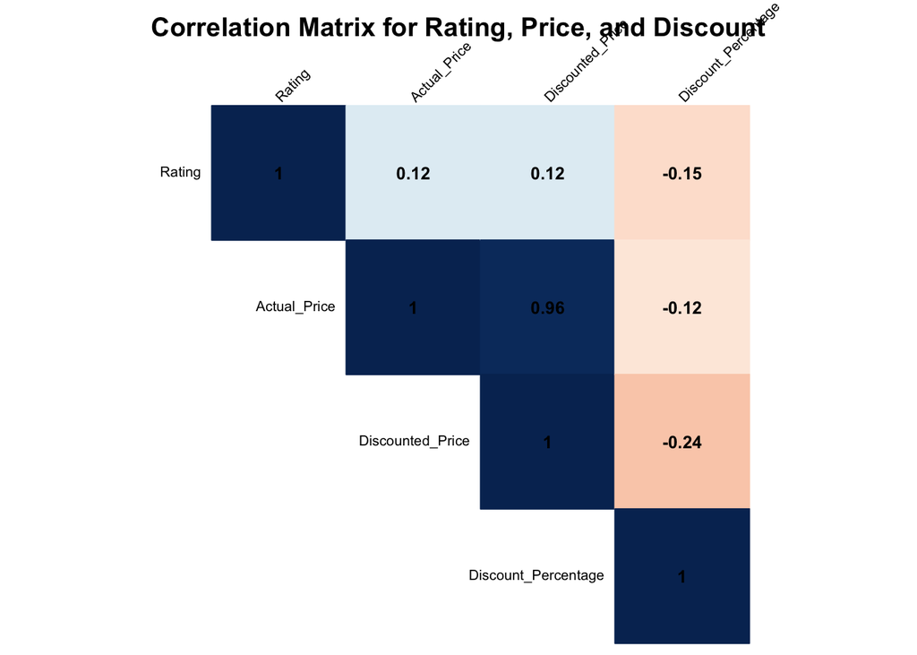

```r
# Set the size of the plotting area
par(mfrow=c(1,1))
par(mar=c(5,5,2,5))

selected_columns <- df1[, c("Rating", "Actual_Price", "Discounted_Price", "Discount_Percentage")]

# Calculating the correlation matrix
correlation_matrix <- cor(selected_columns, use="complete.obs")

# Plotting the correlation matrix
corrplot(correlation_matrix, method="color", type="upper", tl.col="black", tl.srt=45,
         cl.pos="n", addCoef.col="black", number.cex=0.8, tl.cex=0.65)

title("Correlation Matrix for Rating, Price, and Discount")
```

The correlation matrix reveals a minimal impact of both actual and discounted prices on customer satisfaction, indicating that price is not a primary driver of happiness for customers. Despite a strong relationship between actual and discounted prices, suggesting proportional discounts, these factors don’t significantly influence how customers rate their satisfaction. The data hints at a deeper story where satisfaction is less about the discount’s depth and more about perceived quality and overall value. This suggests businesses should focus less on aggressive pricing strategies and more on the quality and service that underpin true customer satisfaction.